# lessson 4 exercise

# 价格与 x

In this problem set, you’ll continue to explore the diamonds data set.

Your first task is to create a scatterplot of price vs x. using the ggplot syntax.

This assignment is not graded and will be marked as correct when you submit.

ENTER YOUR CODE BELOW THIS LINE ===========================================

```r
library(ggplot2)
?diamonds
```

```
## starting httpd help server ... done
```

```r
head(diamonds)
```

| carat | cut | color | clarity | depth | table | price | x | y | z |
| --- | --- | --- | --- | --- | --- | --- | --- | --- | --- |
| 0.23 | Ideal | E | SI2 | 61.5 | 55 | 326 | 3.95 | 3.98 | 2.43 |
| 0.21 | Premium | E | SI1 | 59.8 | 61 | 326 | 3.89 | 3.84 | 2.31 |
| 0.23 | Good | E | VS1 | 56.9 | 65 | 327 | 4.05 | 4.07 | 2.31 |
| 0.29 | Premium | I | VS2 | 62.4 | 58 | 334 | 4.20 | 4.23 | 2.63 |
| 0.31 | Good | J | SI2 | 63.3 | 58 | 335 | 4.34 | 4.35 | 2.75 |
| 0.24 | Very Good | J | VVS2 | 62.8 | 57 | 336 | 3.94 | 3.96 | 2.48 |

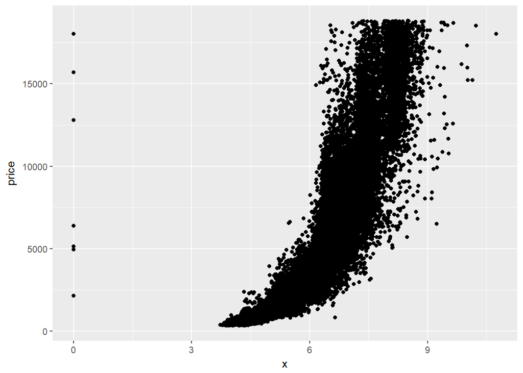

```r
ggplot(aes(x = x, y = price), data = diamonds) +
  geom_point()
```

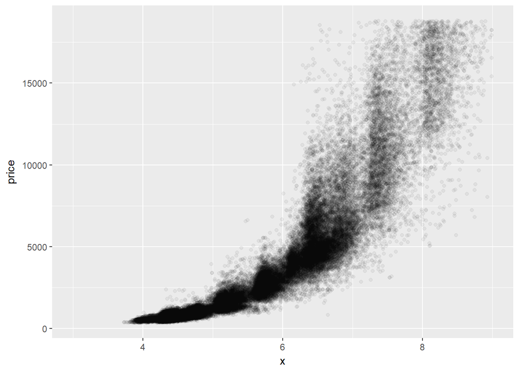

```r
ggplot(aes(x = x, y = price), data = diamonds) +
  geom_point(alpha=0.05) +
  xlim(3, 9)
```

# 相关性

```r
# what is the correlation between price and x?
cor.test(x = diamonds$x, y = diamonds$price, data = diamonds)
```

```
##
##  Pearson's product-moment correlation
##
## data:  diamonds$x and diamonds$price
## t = 440.16, df = 53938, p-value < 2.2e-16
## alternative hypothesis: true correlation is not equal to 0
## 95 percent confidence interval:
##  0.8825835 0.8862594
## sample estimates:
##       cor
## 0.8844352
```

```r
# what is the correlation between price and y?
cor.test(x = diamonds$y, y = diamonds$price, data = diamonds)
```

```
##
##  Pearson's product-moment correlation
##
## data:  diamonds$y and diamonds$price
## t = 401.14, df = 53938, p-value < 2.2e-16
## alternative hypothesis: true correlation is not equal to 0
## 95 percent confidence interval:
##  0.8632867 0.8675241
## sample estimates:
##       cor
## 0.8654209
```

```r
# what is the correlation between price and z?
cor.test(x = diamonds$z, y = diamonds$price, data = diamonds)
```

```
##
##  Pearson's product-moment correlation
##
## data:  diamonds$z and diamonds$price
## t = 393.6, df = 53938, p-value < 2.2e-16
## alternative hypothesis: true correlation is not equal to 0
## 95 percent confidence interval:
##  0.8590541 0.8634131
## sample estimates:
##       cor
## 0.8612494
```

# 价格与深度

Create a simple scatter plot of price vs depth.

This assignment is not graded and will be marked as correct when you submit.

ENTER YOUR CODE BELOW THIS LINE ==================================================

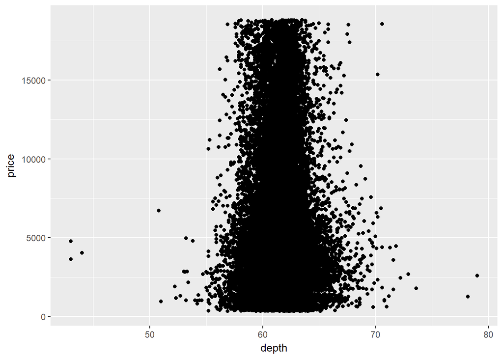

```r
ggplot(aes(x = depth, y = price), data = diamonds) +
  geom_point()
```

# 调整 - 价格与深度

Change the code to make the transparency of the points to be 1/100 of what they are now and mark the x-axis every 2 units. See the instructor notes for two hints.

```r
range(diamonds$depth)
```

```
## [1] 43 79
```

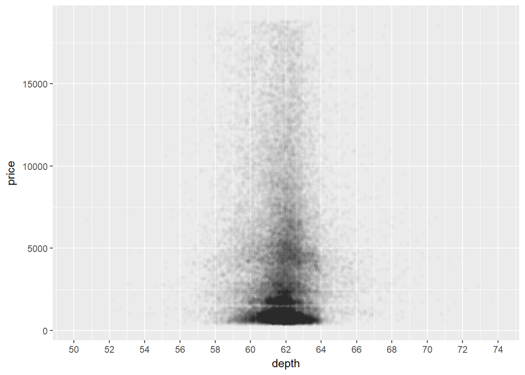

```r
ggplot(aes(x = depth, y = price), data = diamonds) +
  geom_point(alpha = 0.01) +
  scale_x_continuous(breaks = seq(50,74,2), limits = c(50, 74))
```

# 典型深度范围

(59,64)

# 相关性 - 价格与深度

```r
cor.test(x=diamonds$depth, y=diamonds$price)
```

```
##
##  Pearson's product-moment correlation
##
## data:  diamonds$depth and diamonds$price
## t = -2.473, df = 53938, p-value = 0.0134
## alternative hypothesis: true correlation is not equal to 0
## 95 percent confidence interval:
##  -0.019084756 -0.002208537
## sample estimates:
##        cor
## -0.0106474
```

# 价格与克拉

Create a scatterplot of price vs carat and omit the top 1% of price and carat values.

```r
names(diamonds)
```

```
##  [1] "carat"   "cut"     "color"   "clarity" "depth"   "table"   "price"
##  [8] "x"       "y"       "z"
```

```r
summary(diamonds$carat)
```

```
##    Min. 1st Qu.  Median    Mean 3rd Qu.    Max.
##  0.2000  0.4000  0.7000  0.7979  1.0400  5.0100
```

```r
quantile(diamonds$carat, c(.01,.99))
```

```
##   1%  99%
## 0.24 2.18
```

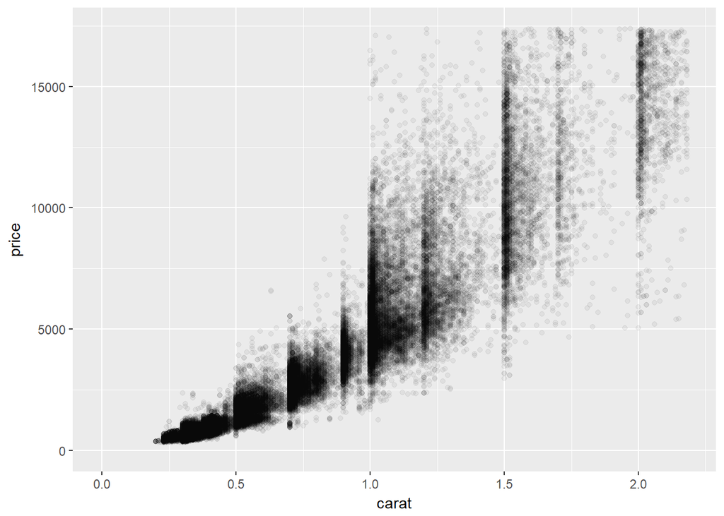

```r
ggplot(aes(x=carat, y=price), data = diamonds) +
  geom_point(alpha=0.05) +
  scale_x_continuous(limits = c(0, quantile(diamonds$carat, 0.99))) +
  scale_y_continuous(limits = c(0, quantile(diamonds$price, 0.99)))
```

# 价格与体积

Create a scatterplot of price vs. volume (x * y * z). This is a very rough approximation for a diamond’s volume.

Create a new variable for volume in the diamonds data frame. This will be useful in a later exercise.

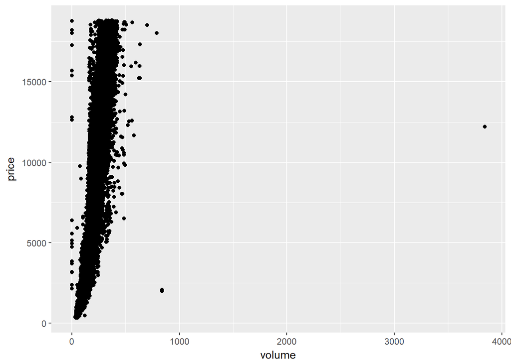

```r
diamonds$volume <- diamonds$x * diamonds$y * diamonds$z

ggplot(aes(x = volume, y = price), data = diamonds) +
  geom_point()
```

# 一些diamonds volume等于0

Did you notice some outliers? Some volumes are 0! There’s an expensive diamond with a volume near 4000, and a cheaper diamond with a volume near 900.

You can find out how many diamonds have 0 volume by using count(diamonds$volume == 0). The count() function comes with the plyr package.

Note: If you ran the count function from plyr, you need to run this command in R to unload the plyr package. detach(“package:plyr”, unload=TRUE) The plyr package will conflict with the dplyr package in later exercises.

Depending on your investigation, it may or may not be important for you to understand how outliers, like these, came to be in your data.

```r
summary(diamonds$volume)
```

```
##    Min. 1st Qu.  Median    Mean 3rd Qu.    Max.
##    0.00   65.14  114.81  129.85  170.84 3840.60
```

```r
Zerodiamonds <- subset(diamonds, diamonds$volume == 0)
dim(Zerodiamonds)[1]
```

```
## [1] 20
```

```r
#View(Zerodiamonds)
#count(diamonds, diamonds$volume == 0)
```

# 子集相关性

提示 1：向钻石数据框中添加一个体积变量很有帮助。你应该排除体积大于或等于 800 的钻石。而且，还要排除体积为 0 的钻石。当你子集化原始数据框时，在两个条件之间使用 & 符号。

提示 2：在这些条件下子集化钻石数据框，并且将它保存到另一个变量中。在 cor() 函数中使用该数据框。

```r
diamonds.sub <- subset(diamonds, diamonds$volume != 0 & diamonds$volume < 800)
cor.test(diamonds.sub$volume, diamonds.sub$price)
```

```
##
##  Pearson's product-moment correlation
##
## data:  diamonds.sub$volume and diamonds.sub$price
## t = 559.19, df = 53915, p-value < 2.2e-16
## alternative hypothesis: true correlation is not equal to 0
## 95 percent confidence interval:
##  0.9222944 0.9247772
## sample estimates:
##       cor
## 0.9235455
```

# 调整 - 价格与体积

Subset the data to exclude diamonds with a volume greater than or equal to 800. Also, exclude diamonds with a volume of 0. Adjust the transparency of the points and add a linear model to the plot. (See the Instructor Notes or look up the documentation of geom_smooth() for more details about smoothers.)

We encourage you to think about this next question and to post your thoughts in the discussion section.

Do you think this would be a useful model to estimate the price of diamonds? Why or why not?

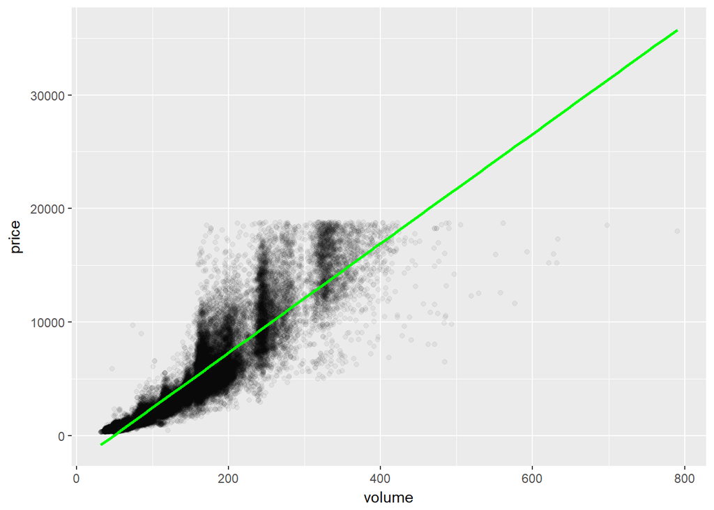

```r
ggplot(aes(x = volume, y = price), data = diamonds.sub) +
  geom_point(alpha = 0.05) +
  geom_smooth(method = 'lm', color = 'green')
```

# 平均价格 - 净度

Use the function dplyr package to create a new data frame containing info on diamonds by clarity.

Name the data frame diamondsByClarity

The data frame should contain the following variables in this order.

```
   (1) mean_price
   (2) median_price
   (3) min_price
   (4) max_price
   (5) n
```

where n is the number of diamonds in each level of clarity.

This assignment WILL BE automatically graded!

DO NOT ALTER THE NEXT THREE LINES OF CODE. ======================================================

注意：如果你在进行此练习之前使用了 plyr 包中的 count() 函数，则需要运行以下命令卸载 plyr 包。 detach(“package:plyr”, unload=TRUE) dplyr包。

重要事项！请注意：在较新版本的 dplyr (0.3.x+) 中，语法 %.% 已被弃用且替换为 %>%。课程视频中使用的是 %.%，但这会产生警告消息。如果您在回答中使用链接运算符，您应该使用 %>%。

另一警告：0.4.0 版本的 dplyr 在汇总层上使用中间值函数时有一个错误，具体取决于被汇总的数据性质。你可能需要将数据转换为数值型（浮点型），以获得期望的结果，比如：median(as.numeric(var))。

```r
library(dplyr)
diamondsByClarity <- diamonds %>%
  group_by(clarity) %>%
  summarise(mean_price = mean(price),
            median_price = median(as.numeric(price)),
            min_price = min(price),
            max_price = max(price),
            n = n())
diamondsByClarity
```

| clarity | mean_price | median_price | min_price | max_price | n |
| --- | --- | --- | --- | --- | --- |
| I1 | 3924.169 | 3344 | 345 | 18531 | 741 |
| SI2 | 5063.029 | 4072 | 326 | 18804 | 9194 |
| SI1 | 3996.001 | 2822 | 326 | 18818 | 13065 |
| VS2 | 3924.989 | 2054 | 334 | 18823 | 12258 |
| VS1 | 3839.455 | 2005 | 327 | 18795 | 8171 |
| VVS2 | 3283.737 | 1311 | 336 | 18768 | 5066 |
| VVS1 | 2523.115 | 1093 | 336 | 18777 | 3655 |
| IF | 2864.839 | 1080 | 369 | 18806 | 1790 |

# 平均价格柱状图

We’ve created summary data frames with the mean price by clarity and color. You can run the code in R to verify what data is in the variables diamonds_mp_by_clarity and diamonds_mp_by_color.

Your task is to write additional code to create two bar plots on one output image using the grid.arrange() function from the package gridExtra.

This assignment is not graded and will be marked as correct when you submit.

See the Instructor Notes for more info on bar charts and for a hint on this task.

DO NOT DELETE THE LINES OF CODE BELOW

```r
library(gridExtra)
```

```r
diamonds_by_clarity <- group_by(diamonds, clarity)
diamonds_mp_by_clarity <- summarise(diamonds_by_clarity, mean_price = mean(price))
diamonds_mp_by_clarity <- arrange(diamonds_mp_by_clarity, clarity)


diamonds_by_color <- group_by(diamonds, color)
diamonds_mp_by_color <- summarise(diamonds_by_color, mean_price = mean(price))


diamonds_mp_by_clarity$clarity <- factor(diamonds_mp_by_clarity$clarity, levels = c("I1", "SI1", "SI2", "VS1", "VS2", "VVS1", "VVS2", "IF"), ordered = TRUE)
#diamonds_mp_by_clarity
#str(diamonds_mp_by_clarity)

diamonds_mp_by_color$color <- factor(diamonds_mp_by_color$color, levels = c("J","I","H","G","F","E","D"), ordered = TRUE)

p1 = ggplot(aes(x = clarity, y = mean_price), data = diamonds_mp_by_clarity) +
  geom_col(color = 'orange', fill = 'green')

diamonds_mp_by_color
```

| color | mean_price |
| --- | --- |
| D | 3169.954 |
| E | 3076.752 |
| F | 3724.886 |
| G | 3999.136 |
| H | 4486.669 |
| I | 5091.875 |
| J | 5323.818 |

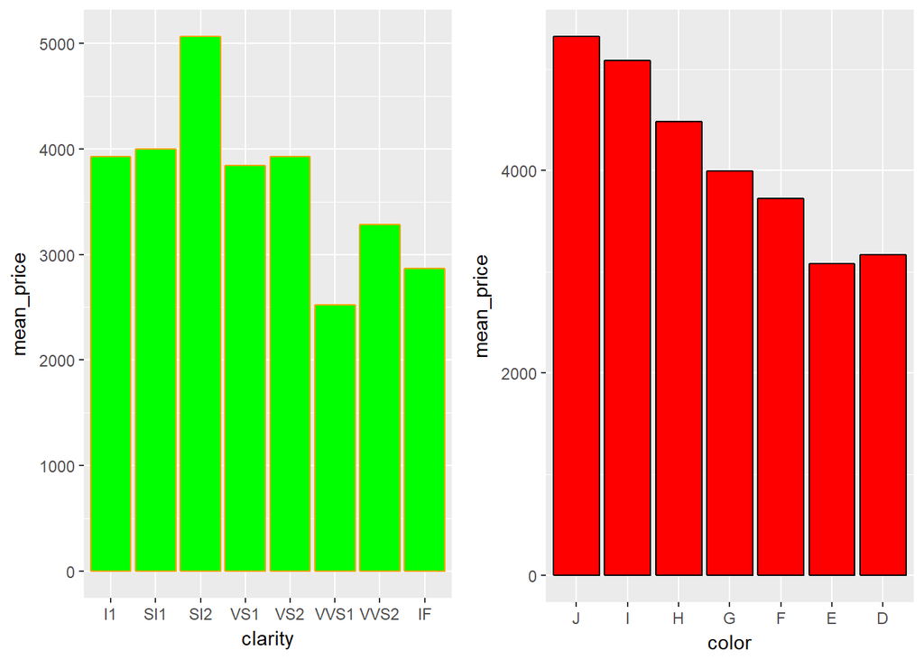

```r
p2 = ggplot(aes(x = color, y = mean_price), data = diamonds_mp_by_color) +
  geom_col(color = 'black', fill = 'red')

grid.arrange(p1, p2, ncol = 2)
```

We think something odd is going here. These trends seem to go against our intuition.

Mean price tends to decrease as clarity improves. The same can be said for color.

# 重访 Gapminder

```r
library(dplyr)
employs <- read.csv("AboveOf15employ.csv", header=T, check.names=F)

names(employs)
```

```
##  [1] "country" "1991"    "1992"    "1993"    "1994"    "1995"    "1996"
##  [8] "1997"    "1998"    "1999"    "2000"    "2001"    "2002"    "2003"
## [15] "2004"    "2005"    "2006"    "2007"    ""
```

```r
#utils::View(employs)
dim(employs)
```

```
## [1] 179  19
```

```r
employs <- dplyr::select(employs, 1:18)
#utils::View(employs)

long_employs <- tidyr::gather(employs, year, employment_rate, 2:18)
#utils::View(long_employs)
str(long_employs)
```

```
## 'data.frame':    3043 obs. of  3 variables:
##  $ country        : Factor w/ 179 levels "","Afghanistan",..: 2 3 4 5 6 7 8 9 10 11 ...
##  $ year           : chr  "1991" "1991" "1991" "1991" ...
##  $ employment_rate: num  56.7 52.7 39.4 75.8 53.6 ...
```

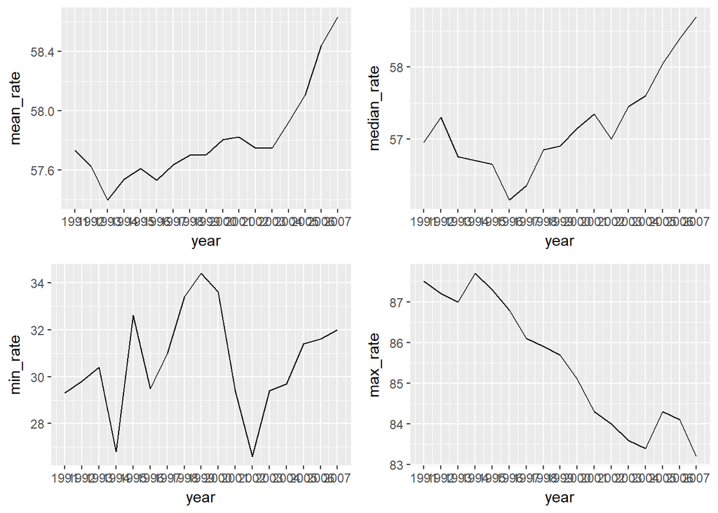

```r
long_employs <- subset(long_employs, !is.na(employment_rate))
long_employs$year <- as.numeric(long_employs$year)

empRateByYear <- long_employs %>%
  group_by(year) %>%
  summarise(mean_rate = mean(employment_rate),
            median_rate = median(as.numeric(employment_rate)),
            min_rate = min(employment_rate),
            max_rate = max(employment_rate),
            n = n())



#View(empRateByYear)

library(gridExtra)
p1 = ggplot(aes(x = year, y = mean_rate), data = empRateByYear) +
  geom_line() +
  scale_x_continuous(breaks = 1991:2007)

p2 = ggplot(aes(x = year, y = median_rate), data = empRateByYear) +
  geom_line() +
  scale_x_continuous(breaks = 1991:2007)

p3 = ggplot(aes(x =year, y = min_rate), data = empRateByYear) +
  geom_line() +
  scale_x_continuous(breaks = 1991:2007)

p4 = ggplot(aes(x =year, y = max_rate), data = empRateByYear) +
  geom_line() +
  scale_x_continuous(breaks = 1991:2007)

grid.arrange(p1, p2, p3, p4, ncol=2)
```